# Project: Investigate a Dataset - Exploring Nicolas Cage

- Introduction
- Data Wrangling
- Exploratory Data Analysis
- Conclusions

## Introduction

In this project, we will investigate a dataset from TMDB containing information on over 10,000 movies. The dataset contains a number of attributes about each movie such as: title, cast, director, runtime, etc.

Throughout the investigation, we will be exploring the data to answer questions about one of America's most iconic actors, Nicolas Cage.

### Questions:

1) What is the average revenue of a Nicolas Cage movie?

2) What is the average runtime for a Nicolas Cage movie in each year?

3) What are Nicolas Cage’s five highest and lowest grossing movies?

4) What is the probability of choosing a random new movie of a specific genre, featuring Nicolas Cage, in each year?

```python
# Libraries needed
import pandas as pd
import numpy as np
import matplotlib.pyplot as plt

# Magic word
%matplotlib inline
```

## Data Wrangling

In this section we will load our dataset into a pandas dataframe, familiarize ourselves with the data attributes, check for cleanliness of the data, and then transform our dataframe into a squeeky-clean version of its former self.

We will then use the cleaned and trimmed dataset to perform exploratory analysis in an attempt to answer our burning questions listed above.

```python
# Read .csv file into a pandas dataframe
df = pd.read_csv("tmdb_movies.csv")

# Print the first 3 rows to check .read_csv worked
df.head(3)
```

|  | id | imdb_id | popularity | budget | revenue | original_title | cast | homepage | director | tagline | ... | overview | runtime | genres | production_companies | release_date | vote_count | vote_average | release_year | budget_adj | revenue_adj |
| --- | --- | --- | --- | --- | --- | --- | --- | --- | --- | --- | --- | --- | --- | --- | --- | --- | --- | --- | --- | --- | --- |
| 0 | 135397 | tt0369610 | 32.985763 | 150000000 | 1513528810 | Jurassic World | Chris Pratt\|Bryce Dallas Howard\|Irrfan Khan\|Vi... | http://www.jurassicworld.com/ | Colin Trevorrow | The park is open. | ... | Twenty-two years after the events of Jurassic ... | 124 | Action\|Adventure\|Science Fiction\|Thriller | Universal Studios\|Amblin Entertainment\|Legenda... | 6/9/15 | 5562 | 6.5 | 2015 | 1.379999e+08 | 1.392446e+09 |
| 1 | 76341 | tt1392190 | 28.419936 | 150000000 | 378436354 | Mad Max: Fury Road | Tom Hardy\|Charlize Theron\|Hugh Keays-Byrne\|Nic... | http://www.madmaxmovie.com/ | George Miller | What a Lovely Day. | ... | An apocalyptic story set in the furthest reach... | 120 | Action\|Adventure\|Science Fiction\|Thriller | Village Roadshow Pictures\|Kennedy Miller Produ... | 5/13/15 | 6185 | 7.1 | 2015 | 1.379999e+08 | 3.481613e+08 |
| 2 | 262500 | tt2908446 | 13.112507 | 110000000 | 295238201 | Insurgent | Shailene Woodley\|Theo James\|Kate Winslet\|Ansel... | http://www.thedivergentseries.movie/#insurgent | Robert Schwentke | One Choice Can Destroy You | ... | Beatrice Prior must confront her inner demons ... | 119 | Adventure\|Science Fiction\|Thriller | Summit Entertainment\|Mandeville Films\|Red Wago... | 3/18/15 | 2480 | 6.3 | 2015 | 1.012000e+08 | 2.716190e+08 |

3 rows × 21 columns

### Great!

Looks like everything was loaded into the dataframe correctly.

Now we will use a few library functions to understand the properties and cleanliness of our dataset.

```python
# Display shape of dataframe (#Rows, #Columns)
df.shape
```

```
(10866, 21)
```

```python
# Retrieve column names, #entries, and data types
df.info()
```

```
<class 'pandas.core.frame.DataFrame'>
RangeIndex: 10866 entries, 0 to 10865
Data columns (total 21 columns):
id                      10866 non-null int64
imdb_id                 10856 non-null object
popularity              10866 non-null float64
budget                  10866 non-null int64
revenue                 10866 non-null int64
original_title          10866 non-null object
cast                    10790 non-null object
homepage                2936 non-null object
director                10822 non-null object
tagline                 8042 non-null object
keywords                9373 non-null object
overview                10862 non-null object
runtime                 10866 non-null int64
genres                  10843 non-null object
production_companies    9836 non-null object
release_date            10866 non-null object
vote_count              10866 non-null int64
vote_average            10866 non-null float64
release_year            10866 non-null int64
budget_adj              10866 non-null float64
revenue_adj             10866 non-null float64
dtypes: float64(4), int64(6), object(11)
memory usage: 1.7+ MB
```

```python
# Show stats about dataframe to build intuition
df.describe()
```

|  | id | popularity | budget | revenue | runtime | vote_count | vote_average | release_year | budget_adj | revenue_adj |
| --- | --- | --- | --- | --- | --- | --- | --- | --- | --- | --- |
| count | 10866.000000 | 10866.000000 | 1.086600e+04 | 1.086600e+04 | 10866.000000 | 10866.000000 | 10866.000000 | 10866.000000 | 1.086600e+04 | 1.086600e+04 |
| mean | 66064.177434 | 0.646441 | 1.462570e+07 | 3.982332e+07 | 102.070863 | 217.389748 | 5.974922 | 2001.322658 | 1.755104e+07 | 5.136436e+07 |
| std | 92130.136561 | 1.000185 | 3.091321e+07 | 1.170035e+08 | 31.381405 | 575.619058 | 0.935142 | 12.812941 | 3.430616e+07 | 1.446325e+08 |
| min | 5.000000 | 0.000065 | 0.000000e+00 | 0.000000e+00 | 0.000000 | 10.000000 | 1.500000 | 1960.000000 | 0.000000e+00 | 0.000000e+00 |
| 25% | 10596.250000 | 0.207583 | 0.000000e+00 | 0.000000e+00 | 90.000000 | 17.000000 | 5.400000 | 1995.000000 | 0.000000e+00 | 0.000000e+00 |
| 50% | 20669.000000 | 0.383856 | 0.000000e+00 | 0.000000e+00 | 99.000000 | 38.000000 | 6.000000 | 2006.000000 | 0.000000e+00 | 0.000000e+00 |
| 75% | 75610.000000 | 0.713817 | 1.500000e+07 | 2.400000e+07 | 111.000000 | 145.750000 | 6.600000 | 2011.000000 | 2.085325e+07 | 3.369710e+07 |
| max | 417859.000000 | 32.985763 | 4.250000e+08 | 2.781506e+09 | 900.000000 | 9767.000000 | 9.200000 | 2015.000000 | 4.250000e+08 | 2.827124e+09 |

### Let's clean up our dataframe by eliminating non-pertinent variable columns.

Since we already have a built-in index:

- id
- imdb_id

Variables that do not relate to our questions:

- popularity
- budget
- homepage
- director
- tagline
- keywords
- overview
- production_companies
- release_date

Variables that may have been useful or interesting, but there is no documentation on what they represent:

- vote_count
- vote_average
- budget_adj
- revenue_adj

```python
# Drop all columns listed in above cell
df.drop(labels = ['id','imdb_id','popularity','budget','homepage','director',
                  'tagline','keywords','overview','production_companies','release_date',
                  'vote_count','vote_average','budget_adj','revenue_adj'], axis = 1, inplace = True)
```

We will also eliminate any duplicate rows in our dataframe

```python
# Drop any duplicate rows
df.drop_duplicates(keep='first', inplace=True)
```

Now we will check that the dataframe has been properly trimmed down to six attribute columns:

- revenue
- original_title
- cast
- runtime
- genres
- release_year

```python
# Check trimmed dateframe
df.head()
```

|  | revenue | original_title | cast | runtime | genres | release_year |
| --- | --- | --- | --- | --- | --- | --- |
| 0 | 1513528810 | Jurassic World | Chris Pratt\|Bryce Dallas Howard\|Irrfan Khan\|Vi... | 124 | Action\|Adventure\|Science Fiction\|Thriller | 2015 |
| 1 | 378436354 | Mad Max: Fury Road | Tom Hardy\|Charlize Theron\|Hugh Keays-Byrne\|Nic... | 120 | Action\|Adventure\|Science Fiction\|Thriller | 2015 |
| 2 | 295238201 | Insurgent | Shailene Woodley\|Theo James\|Kate Winslet\|Ansel... | 119 | Adventure\|Science Fiction\|Thriller | 2015 |
| 3 | 2068178225 | Star Wars: The Force Awakens | Harrison Ford\|Mark Hamill\|Carrie Fisher\|Adam D... | 136 | Action\|Adventure\|Science Fiction\|Fantasy | 2015 |
| 4 | 1506249360 | Furious 7 | Vin Diesel\|Paul Walker\|Jason Statham\|Michelle ... | 137 | Action\|Crime\|Thriller | 2015 |

### Super!

Now we will check to see if there are any missing values in our remaining data

```python
# Counts number of null values by column
df.isnull().sum()
```

```
revenue            0
original_title     0
cast              76
runtime            0
genres            23
release_year       0
dtype: int64
```

We have a few missing values in our **cast** and **genres** columns.

We need to know with certainty if Nicolas Cage was in a movie or not and the genres of each movie to answer our questions. Since there are relatively few instances of these attributes containing a null value we will simply drop those entries from our dataset.

```python
# Drop entries with "Null" value in cast column
df.dropna(subset=['cast'], inplace=True)
```

```python
# Drop entries with "Null" value in genres column
df.dropna(subset=['genres'], inplace=True)
```

Now we will run the .isnull() function again to check that it worked.

```python
# Counts number of null values by column (should all now be 0)
df.isnull().sum()
```

```
revenue           0
original_title    0
cast              0
runtime           0
genres            0
release_year      0
dtype: int64
```

### Fantastic!

Although, I have a sneaking suspicion that there are values in the integer columns that are '0' instead of null... Let's check!

```python
# Number of entries with "0" in revenue column
df[df.revenue == 0].count()
```

```
revenue           5923
original_title    5923
cast              5923
runtime           5923
genres            5923
release_year      5923
dtype: int64
```

```python
# Number of entries with "0" in runtime column
df[df.runtime == 0].count()
```

```
revenue           30
original_title    30
cast              30
runtime           30
genres            30
release_year      30
dtype: int64
```

```python
# Number of entries with "0" in release_year column
df[df.release_year == 0].count()
```

```
revenue           0
original_title    0
cast              0
runtime           0
genres            0
release_year      0
dtype: int64
```

Just as I feared! We need to deal with the "0" values in the **revenue** and **runtime** columns to avoid skewing any analysis we perform on those attributes.

```python
# Replace "0" with NaN using NumPy
df.revenue.replace(0, np.nan, inplace=True)
```

```python
# Replace "0" with NaN using NumPy
df.runtime.replace(0, np.nan, inplace=True)
```

We can now check to see if our code worked.

```python
# Number of entries with "0" in revenue column
df[df.revenue == 0].count()
```

```
revenue           0
original_title    0
cast              0
runtime           0
genres            0
release_year      0
dtype: int64
```

```python
# Number of entries with "0" in runtime column
df[df.runtime == 0].count()
```

```
revenue           0
original_title    0
cast              0
runtime           0
genres            0
release_year      0
dtype: int64
```

```python
df.info()
```

```
<class 'pandas.core.frame.DataFrame'>
Int64Index: 10767 entries, 0 to 10865
Data columns (total 6 columns):
revenue           4844 non-null float64
original_title    10767 non-null object
cast              10767 non-null object
runtime           10737 non-null float64
genres            10767 non-null object
release_year      10767 non-null int64
dtypes: float64(2), int64(1), object(3)
memory usage: 588.8+ KB
```

### Success!

We now have a dataset with <1% of entries trimmed off the original containing:

- Proper datatypes
- No "Null" values in columns with strings
- No "0" values in columns with numbers

We can now perform our analysis on the cleaned dataset to answer our questions!

> On second thought... I would prefer if the column order was changed for easier readability. Let's do that quickly before we begin.

```python
# Assigns dateframe with more pleasing column order
df = df[['original_title', 'cast', 'genres', 'revenue', 'runtime', 'release_year']]
```

```python
# Checks that everything worked
df.head()
```

|  | original_title | cast | genres | revenue | runtime | release_year |
| --- | --- | --- | --- | --- | --- | --- |
| 0 | Jurassic World | Chris Pratt\|Bryce Dallas Howard\|Irrfan Khan\|Vi... | Action\|Adventure\|Science Fiction\|Thriller | 1.513529e+09 | 124.0 | 2015 |
| 1 | Mad Max: Fury Road | Tom Hardy\|Charlize Theron\|Hugh Keays-Byrne\|Nic... | Action\|Adventure\|Science Fiction\|Thriller | 3.784364e+08 | 120.0 | 2015 |
| 2 | Insurgent | Shailene Woodley\|Theo James\|Kate Winslet\|Ansel... | Adventure\|Science Fiction\|Thriller | 2.952382e+08 | 119.0 | 2015 |
| 3 | Star Wars: The Force Awakens | Harrison Ford\|Mark Hamill\|Carrie Fisher\|Adam D... | Action\|Adventure\|Science Fiction\|Fantasy | 2.068178e+09 | 136.0 | 2015 |
| 4 | Furious 7 | Vin Diesel\|Paul Walker\|Jason Statham\|Michelle ... | Action\|Crime\|Thriller | 1.506249e+09 | 137.0 | 2015 |

### Amazing!

We will now use this beautiful dataset to answer our questions.

## Exploratory Data Analysis

Now we are ready to move on to data exploration. We will calculate a couple statistical values and answer our questions.

### Q1) What is the average revenue of a Nicolas Cage movie?

Our first question is easy to answer now that we have properly cleaned and trimmed our dataset. We will create a new dataframe of only Nicolas Cage films and run a simple .mean() function over the revenue column.

```python
# Create dataframe subset of only Nicolas Cage movies
df_cage = df[df.cast.str.contains('Nicolas Cage')]
```

```python
# Calculate mean revenue of all Nicolas Cage movies
df_cage.revenue.mean()
```

```
105791063.56521739
```

And just like that, we know the average revenue for a Nicolas Cage movie is $105,791,063!

### Q2) What is the average runtime for a Nicolas Cage movie in each year?

We will use a .groupby() function to group all Nicolas Cage movies by their release_year column and then run a .mean() function over the runtime column to find and plot the average runtime in each year.

```python
# Group movies by release_year and assign to new dataframe
df_cage_year = df_cage.groupby('release_year')

# Calculate mean runtime in each year and assign to runtime column
df_cage_year.runtime = df_cage_year.runtime.mean()
```

```python
df_cage_year.runtime.index
```

```
Int64Index([1983, 1984, 1986, 1987, 1988, 1990, 1991, 1992, 1993, 1994, 1995,
            1996, 1997, 1998, 1999, 2000, 2001, 2002, 2003, 2004, 2005, 2006,
            2007, 2008, 2009, 2010, 2011, 2012, 2013, 2014, 2015],
           dtype='int64', name='release_year')
```

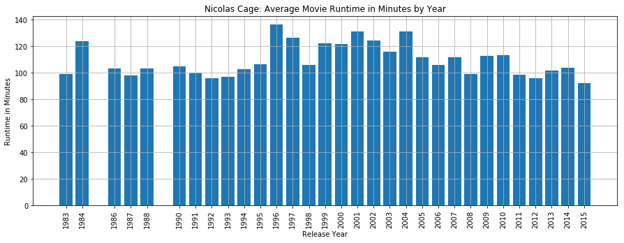

```python
# Plot bar chart with PyPlot
plt.figure(figsize = (15,5))
plt.bar(df_cage_year.runtime.index,
        df_cage_year.runtime)
plt.title('Nicolas Cage: Average Movie Runtime in Minutes by Year')
plt.xlabel('Release Year')
plt.ylabel('Runtime in Minutes')
plt.xticks(df_cage_year.runtime.index, rotation = 90)
plt.grid(b = True)
```

We can see that the above chart shows the average runtime of all Nicolas Cage movies released in each year. 1996 had the highest average runtime at 136 minutes, and 2015 had the lowest average runtime at 92 minutes. The average runtime trends highest during the mid 90's and early 2000's, with a general tappering down until the end of the dataset in 2015. 1985 and 1989 were the only two years during his career that a Nicolas Cage movie wasn't released.

### Q3) What are Nicolas Cage's Five Highest and Lowest Grossing Movies?

Our third question will require a bit more data manipulation. We will create new dataframes by sorting our df_cage dataframe by descending and ascending revenue, taking only the header, and assigning them to new dataframes for top 5 and bottom 5 respectively.

```python
# Creates top 5 dataframe
df_cage_top5 = df_cage.sort_values('revenue', ascending=False).head()
```

```python
# Display the new dataframe
df_cage_top5
```

|  | original_title | cast | genres | revenue | runtime | release_year |
| --- | --- | --- | --- | --- | --- | --- |
| 5483 | The Croods | Nicolas Cage\|Emma Stone\|Ryan Reynolds\|Catherin... | Adventure\|Animation\|Comedy\|Family\|Fantasy | 585178928.0 | 98.0 | 2013 |
| 7393 | National Treasure: Book of Secrets | Nicolas Cage\|Jon Voight\|Harvey Keitel\|Ed Harri... | Action\|Adventure\|Mystery\|Thriller | 457363168.0 | 124.0 | 2007 |
| 6970 | National Treasure | Nicolas Cage\|Diane Kruger\|Justin Bartha\|Sean B... | Adventure\|Action\|Thriller\|Mystery | 347451894.0 | 131.0 | 2004 |
| 8461 | The Rock | Sean Connery\|Nicolas Cage\|Ed Harris\|John Spenc... | Action\|Adventure\|Thriller | 335062621.0 | 136.0 | 1996 |
| 5250 | Face/Off | John Travolta\|Nicolas Cage\|Joan Allen\|Alessand... | Action\|Crime\|Science Fiction\|Thriller | 245676146.0 | 138.0 | 1997 |

Now we will change our revenue column to represent millions and plot the df_cage_top5 dataframe

```python
# Represents revenue in millions
df_cage_top5.revenue = df_cage_top5.revenue/1000000
```

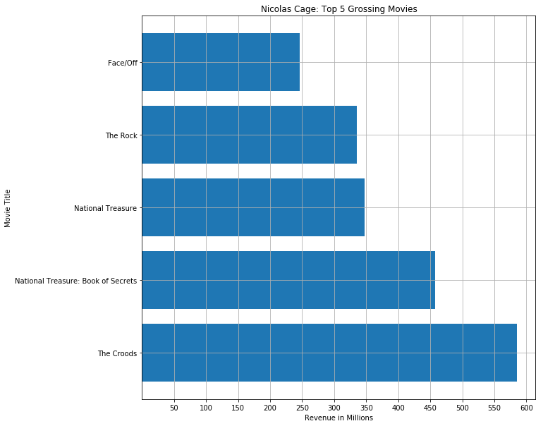

```python
# Plot horizontal bar chart with PyPlot
plt.figure(figsize=(10,10))
plt.barh(df_cage_top5.original_title,
        df_cage_top5.revenue)
plt.xlabel("Revenue in Millions")
plt.ylabel("Movie Title")
plt.title("Nicolas Cage: Top 5 Grossing Movies")
plt.xticks([50,100,150,200,250,300,350,400,450,500,550,600])
plt.grid(b = True)
```

We can repeat the same process for the 5 lowest grossing movies

```python
# Creates bottom 5 dataframe
df_cage_low5 = df_cage.sort_values('revenue', ascending=True).head()
```

```python
# Display the new dataframe
df_cage_low5
```

|  | original_title | cast | genres | revenue | runtime | release_year |
| --- | --- | --- | --- | --- | --- | --- |
| 9571 | Vampire's Kiss | Nicolas Cage\|María Conchita Alonso\|Jennifer B... | Comedy\|Fantasy\|Horror | 725131.0 | 103.0 | 1988 |
| 10323 | Red Rock West | Nicolas Cage\|Dennis Hopper\|Lara Flynn Boyle\|J.... | Crime\|Drama\|Thriller | 2000000.0 | 98.0 | 1993 |
| 4439 | Stolen | Nicolas Cage\|Malin Åkerman\|Josh Lucas\|Sami Ga... | Action\|Crime\|Drama\|Thriller | 2106557.0 | 96.0 | 2012 |
| 985 | Joe | Nicolas Cage\|Tye Sheridan\|Ronnie Gene Blevins\|... | Drama | 2365467.0 | 118.0 | 2014 |
| 5578 | The Frozen Ground | Nicolas Cage\|Vanessa Hudgens\|John Cusack\|Radha... | Thriller\|Crime | 5496951.0 | 105.0 | 2013 |

Now we will plot the df_cage_low5 dataframe with the same change of revenue to millions.

```python
# Represents revenue in millions
df_cage_low5.revenue = df_cage_low5.revenue/1000000
```

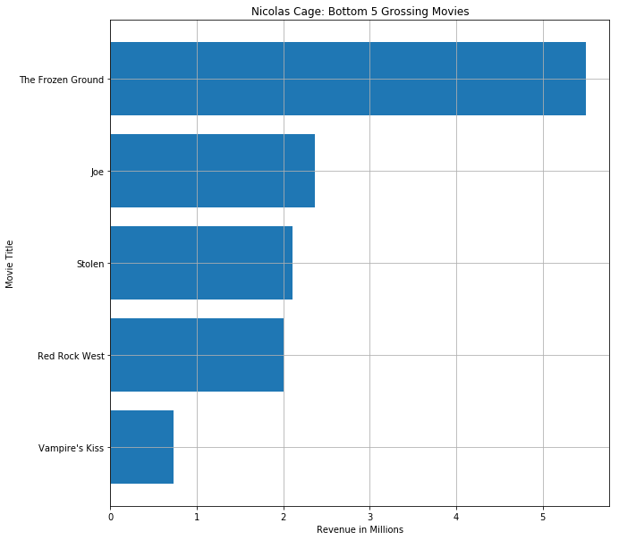

```python
# Plot horizontal bar chart with PyPlot
plt.figure(figsize=(10,10))
plt.barh(df_cage_low5.original_title,
        df_cage_low5.revenue)
plt.xlabel("Revenue in Millions")
plt.ylabel("Movie Title")
plt.title("Nicolas Cage: Bottom 5 Grossing Movies")
plt.grid(b = True)
```

We now have an acceptable answer to our third question.

Top 5 Grossing Movies:

- The Croods ($585,178,928)
- National Treasure: Book of Secrets ($457,363,168)
- National Treasure ($347,451,894)
- The Rock ($335,062,621)
- Face/Off ($245,676,146)

Bottom 5 Grossing Movies:

- Vampire's Kiss ($725,131)
- Red Rock West ($2,000,000)
- Stolen ($2,106,557)
- Joe ($2,365,467)
- The Frozen Ground ($5,496,951)

### Q4) What is the probability of choosing a random new movie of a specific genre, featuring Nicolas Cage, in each year?

Our final question will take a considerable amount of work to answer. We will have to:

- Create a list of all available genres
- Create a list of all release years
- Write a function to find the number of movies in each genre for a given year
- Write a function to compile each result of the previous function into a list of lists
- Transform the list of lists into a dataframe
- Repeat the process for our Nicolas Cage subset
- Calculate the probability for each genre in each year
- Plot our findings

```python
### Create list of all genres (20 values)

# Split string by "|"
temp_1 = df.genres.str.split('|' , expand = True)

# Convert all values to a list
temp_2 = temp_1.values.reshape(-1,).tolist()

# Convert back to single column dataframe for manipulation
genre_list = pd.DataFrame(temp_2)

# Remove null values
genre_list.dropna(inplace = True)

# Retrive unique values
genre_list = genre_list[0].unique()

# Sort unique values
genre_list.sort()

# Check list
genre_list
```

```
array(['Action', 'Adventure', 'Animation', 'Comedy', 'Crime',
       'Documentary', 'Drama', 'Family', 'Fantasy', 'Foreign', 'History',
       'Horror', 'Music', 'Mystery', 'Romance', 'Science Fiction',
       'TV Movie', 'Thriller', 'War', 'Western'], dtype=object)
```

```python
### Create list of all release years (56 values)

# Retrive unique values of release_year in our dataset
year_list = df.release_year.unique()

# Sort list chronologically
year_list.sort()

# Check list
year_list
```

```
array([1960, 1961, 1962, 1963, 1964, 1965, 1966, 1967, 1968, 1969, 1970,
       1971, 1972, 1973, 1974, 1975, 1976, 1977, 1978, 1979, 1980, 1981,
       1982, 1983, 1984, 1985, 1986, 1987, 1988, 1989, 1990, 1991, 1992,
       1993, 1994, 1995, 1996, 1997, 1998, 1999, 2000, 2001, 2002, 2003,
       2004, 2005, 2006, 2007, 2008, 2009, 2010, 2011, 2012, 2013, 2014,
       2015], dtype=int64)
```

```python
### Function that searches for number of movies in each genre for a chosen year
### and returns a list of values in alphabetical order

def fill_genre(year):

    year_values = []
    genre_list = ['Action', 'Adventure', 'Animation', 'Comedy', 'Crime',
       'Documentary', 'Drama', 'Family', 'Fantasy', 'Foreign', 'History',
       'Horror', 'Music', 'Mystery', 'Romance', 'Science Fiction',
       'TV Movie', 'Thriller', 'War', 'Western']

    # Iterate over genre_list and search for movies in given year and genre
    # then count them and append them to the year_values list
    for i in range(len(genre_list)):
        year_values.append(df[(df.release_year == year) &
                              (df.genres.str.contains(genre_list[i]))].original_title.count())

    return year_values
```

```python
### Function that will repeat the fill_genre function for every year of our dataset
### then add the list from the fill_genre function to a list of lists to create our
### new dataframe

def load_data():

    l_of_l = []

    # Itirates over the 56 years of data in our dataset
    # and appends the results of fill_genre() to a list of lists
    for i in range(56):
        l_of_l.append(fill_genre((1960 + i)))

    return l_of_l
```

```python
# Load data into variable
Full_Genre_Data_by_Year = load_data()
```

```python
# Create new full genre dataframe
Full_Genre_DF = pd.DataFrame(data = Full_Genre_Data_by_Year, index = year_list, columns = genre_list)
```

```python
# Check dataframe
Full_Genre_DF.head()
```

|  | Action | Adventure | Animation | Comedy | Crime | Documentary | Drama | Family | Fantasy | Foreign | History | Horror | Music | Mystery | Romance | Science Fiction | TV Movie | Thriller | War | Western |
| --- | --- | --- | --- | --- | --- | --- | --- | --- | --- | --- | --- | --- | --- | --- | --- | --- | --- | --- | --- | --- |
| 1960 | 8 | 5 | 0 | 8 | 2 | 0 | 13 | 3 | 2 | 1 | 5 | 7 | 1 | 0 | 6 | 3 | 0 | 6 | 2 | 6 |
| 1961 | 7 | 6 | 1 | 10 | 2 | 0 | 16 | 5 | 2 | 1 | 3 | 3 | 2 | 1 | 7 | 4 | 0 | 0 | 2 | 3 |
| 1962 | 8 | 7 | 0 | 5 | 3 | 0 | 21 | 2 | 1 | 1 | 4 | 5 | 1 | 4 | 5 | 2 | 0 | 7 | 3 | 3 |
| 1963 | 4 | 7 | 1 | 13 | 4 | 0 | 13 | 3 | 2 | 2 | 4 | 9 | 0 | 6 | 8 | 2 | 0 | 10 | 1 | 2 |
| 1964 | 5 | 5 | 2 | 16 | 10 | 0 | 20 | 4 | 4 | 1 | 3 | 6 | 5 | 4 | 9 | 4 | 0 | 9 | 3 | 1 |

Now we will repeat the process for our Nicolas Cage subset!

```python
### Function that searches our Nicolas Cage dataframe for
### number of movies in each genre for a chosen year
### and returns a list of values in alphabetical order

def fill_genre_cage(year):

    year_values = []
    genre_list = ['Action', 'Adventure', 'Animation', 'Comedy', 'Crime',
       'Documentary', 'Drama', 'Family', 'Fantasy', 'Foreign', 'History',
       'Horror', 'Music', 'Mystery', 'Romance', 'Science Fiction',
       'TV Movie', 'Thriller', 'War', 'Western']

    # Iterate over genre_list and search our Nicolas Cage dataframe
    # for movies in given year and genre then
    # count them and append them to the year_values list
    for i in range(len(genre_list)):
        year_values.append(df_cage[(df_cage.release_year == year) &
                              (df_cage.genres.str.contains(genre_list[i]))].original_title.count())

    return year_values
```

```python
### Function that will repeat the fill_genre function for every year
### of our full dataset then add the list from the fill_genre function
### to a list of lists to create our new Nicolas Cage dataframe

def load_data_cage():

    l_of_l = []

    # Itirates over the 56 years of data in our dataset
    # and appends the results of fill_genre() to a list of lists
    for i in range(56):
        l_of_l.append(fill_genre_cage((1960 + i)))

    return l_of_l
```

```python
# Load data into variable
Cage_Genre_Data_by_Year = load_data_cage()
```

```python
# Create new Nicolas Cage genre dataframe
Cage_Genre_DF = pd.DataFrame(data = Cage_Genre_Data_by_Year, index = year_list, columns = genre_list)
```

```python
# Check dataframe
Cage_Genre_DF.head()
```

|  | Action | Adventure | Animation | Comedy | Crime | Documentary | Drama | Family | Fantasy | Foreign | History | Horror | Music | Mystery | Romance | Science Fiction | TV Movie | Thriller | War | Western |
| --- | --- | --- | --- | --- | --- | --- | --- | --- | --- | --- | --- | --- | --- | --- | --- | --- | --- | --- | --- | --- |
| 1960 | 0 | 0 | 0 | 0 | 0 | 0 | 0 | 0 | 0 | 0 | 0 | 0 | 0 | 0 | 0 | 0 | 0 | 0 | 0 | 0 |
| 1961 | 0 | 0 | 0 | 0 | 0 | 0 | 0 | 0 | 0 | 0 | 0 | 0 | 0 | 0 | 0 | 0 | 0 | 0 | 0 | 0 |
| 1962 | 0 | 0 | 0 | 0 | 0 | 0 | 0 | 0 | 0 | 0 | 0 | 0 | 0 | 0 | 0 | 0 | 0 | 0 | 0 | 0 |
| 1963 | 0 | 0 | 0 | 0 | 0 | 0 | 0 | 0 | 0 | 0 | 0 | 0 | 0 | 0 | 0 | 0 | 0 | 0 | 0 | 0 |
| 1964 | 0 | 0 | 0 | 0 | 0 | 0 | 0 | 0 | 0 | 0 | 0 | 0 | 0 | 0 | 0 | 0 | 0 | 0 | 0 | 0 |

### Wonderful!

We will now create a new dataframe representing the probability of choosing a random new movie of a specific genre, featuring Nicolas Cage, in each year.

To do this, we will divide our Cage_Genre dataframe by our Full_Genre dataframe.

```python
# Calculate probability in new dataframe
Cage_Prob = (Cage_Genre_DF / Full_Genre_DF)
```

```python
# Fill any NaN's caused by 0/0 with "0"
Cage_Prob = Cage_Prob.fillna(0)
```

### Easy!

We now have the dataset necessary to plot the answer to our final question. Huzzah!

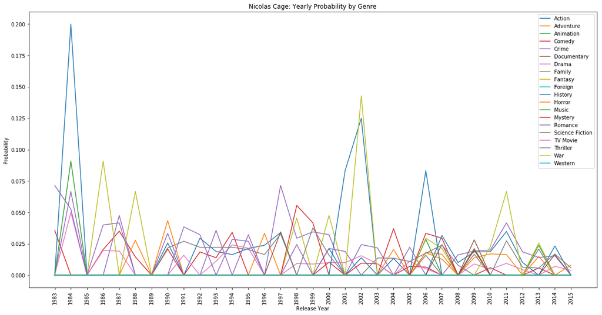

```python
plt.figure(figsize = (20,10))
plt.plot(Cage_Prob[Cage_Prob.index > 1982])
plt.legend(Cage_Prob.columns)
plt.xticks([1983, 1984, 1985, 1986, 1987, 1988, 1989, 1990, 1991, 1992,
       1993, 1994, 1995, 1996, 1997, 1998, 1999, 2000, 2001, 2002, 2003,
       2004, 2005, 2006, 2007, 2008, 2009, 2010, 2011, 2012, 2013, 2014,
       2015], rotation = 90)
plt.xlabel("Release Year")
plt.ylabel("Probability")
plt.title("Nicolas Cage: Yearly Probability by Genre")
```

The two main takeaways from the above chart are:

1) Nicolas Cage has acted in 16 out of the 20 genres contained in a dataset of over 10,000 films. He is a man of many characters and has a very wide range as an actor.

2) There are two instances of surprisingly high probablity. First, Nicolas Cage has a 20% chance of being picked randomly from a list of all history movies released in 1984. Second, Nicholas Cage has almost a 15% chance of being picked randomly from a list of all war movies released in 2002.

## Conclusion

In summary, Pandas is a very useful tool for digging into datasets and extracting valuable information. In a simple project we were able to show:

1) Nicolas Cage's movies gross an average of $105,791,063.

2) The average runtime for a Nicolas Cage movie in each year, which can be seen in the chart "Nicolas Cage: Average Runtime in Minutes by Year"

3) Nicolas Cage's top and bottom 5 grossing movies:

Top 5 Grossing Movies:

- The Croods ($585,178,928)
- National Treasure: Book of Secrets ($457,363,168)
- National Treasure ($347,451,894)
- The Rock ($335,062,621)
- Face/Off ($245,676,146)

Bottom 5 Grossing Movies:

- Vampire's Kiss ($725,131)
- Red Rock West ($2,000,000)
- Stolen ($2,106,557)
- Joe ($2,365,467)
- The Frozen Ground ($5,496,951)

4) The probability of choosing a random new movie of a specific genre, featuring Nicolas Cage, in each year, which can be seen in the previous chart.

Overall, we can see that Nicolas Cage is certainly an iconic American actor. He averages over $100million in every movie he's been in and has acted in movies spanning all but 4 (western, documentary, TV movie, and foreign) of the 20 genres in our dataset.

### Limitations

1) We have used TMBD Movies dataset for our analysis and worked with original_title, genre, cast, release_year, revenue, and runtime. Our analysis is limited to only provided dataset. For example, the dataset does not confirm that every Nicolas Cage movie released is contained in the dataset.

2) Dropping missing or Null values from variables that we utilized in our project might skew our analysis and could show unintentional bias towards having a higher probability of Nicolas Cage being picked.

**I hope you enjoyed the journey!**

**-Nicholas Hodges**